# State MSM Profile: **South Carolina**

### Background & Methods

In 2015-2016, researchers at Emory University partnered with colleagues at the Centers for Disease Control and Prevention (CDC) to develop methods to estimate the number of men who have sex with men (MSM) residing in each county in the United States. Using population and housing data from the [American Community Survey](https://www.census.gov/programs-surveys/acs/) and estimates from two peer-reviewed publications ([Oster et al., 2015](http://www.ncbi.nlm.nih.gov/pubmed/26115985) & [Purcell et al., 2012](http://www.ncbi.nlm.nih.gov/pubmed/23049658)), they derived an indirect estimate of MSM population sizes that took into account both the urbanicity of the county as well as its density of households with a male householder and a male same-sex partner.

The full methodology is published in the *Journal of Medical Internet Research - Public Health and Surveillance*:

> [Grey JA, Bernstein KT, Sullivan PS, Purcell DW, Chesson HW, Gift TL, Rosenberg ES. Estimating the population sizes of men who have sex with men in US states and counties using data from the American Community Survey. JMIR Public Health Surveill 2016;2(1):e14. DOI: 10.2196/publichealth.5365](http://publichealth.jmir.org/2016/1/e14/)

### Overview of MSM in South Carolina

An estimated **36,316** men who have sex with men (MSM) resided in South Carolina in 2013, representing 0.8% of the 4,503,084 MSM in the United States. Of the 1,726,807 adult men of South Carolina, 2.1% had had sex with another man in the past 5 years, which was less than the overall percentage of adult men in the United States who were MSM (3.9%).

Most MSM in South Carolina resided in counties within medium or small metropolitan areas (76.0%). Including both central and fringe counties, 10.7% resided in a large metropolitan area.

##### **Percentage of MSM by urbanicity, United States and South Carolina, 2013**

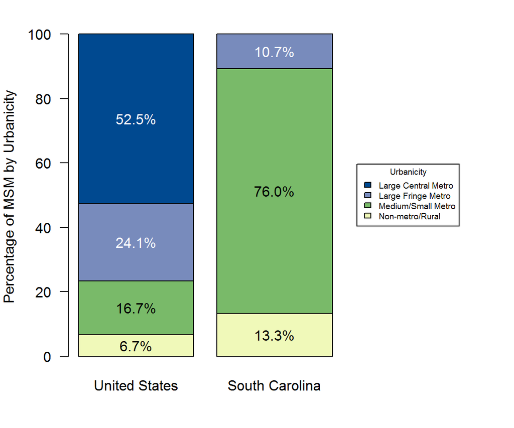

### MSM in South Carolina Counties

Among counties or county-equivalent areas in South Carolina, Greenville County had the largest population of MSM at 3,761, representing 10.4% of all MSM in the state. Jasper County had the highest percentage of MSM among adult men in South Carolina at 3.8%. This was greater than the percentage for South Carolina as a whole, which was 2.1% of adult men.

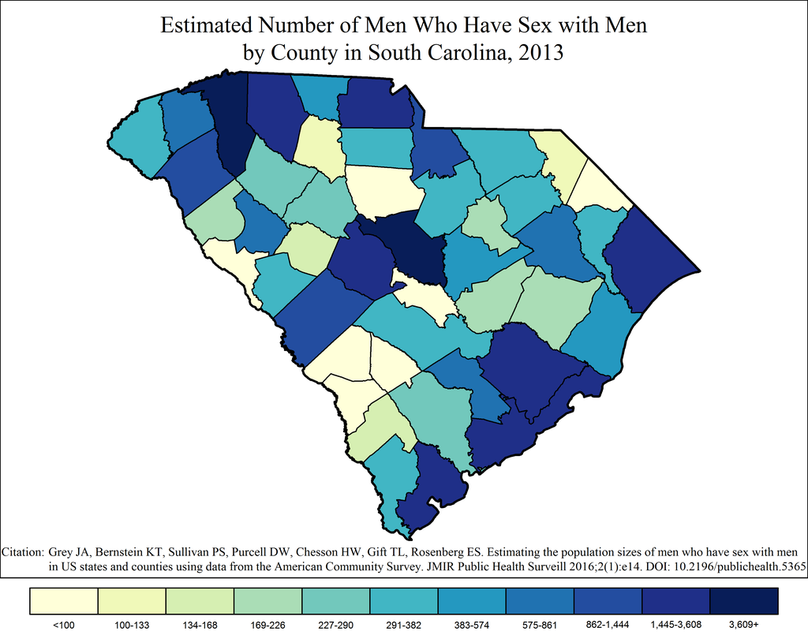

Note: Range cutpoints for the map are based on the distribution of MSM among all counties in the United States.

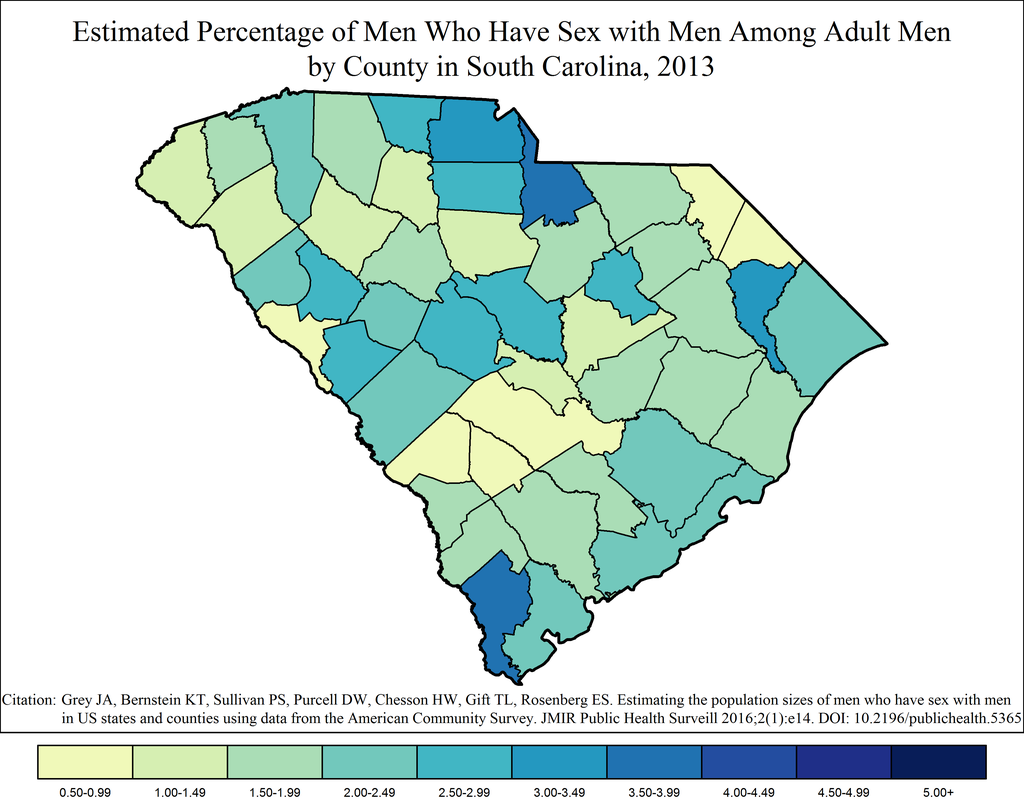

### MSM in South Carolina Metropolitan Statistical Areas

#### Columbia Metropolitan Statistical Area

The Columbia MSA had the largest metropolitan population of MSM in South Carolina at 6,937, or 19.1% of all MSM in the state. Of the 286,547 adult men in Columbia, an estimated 2.4% were MSM.

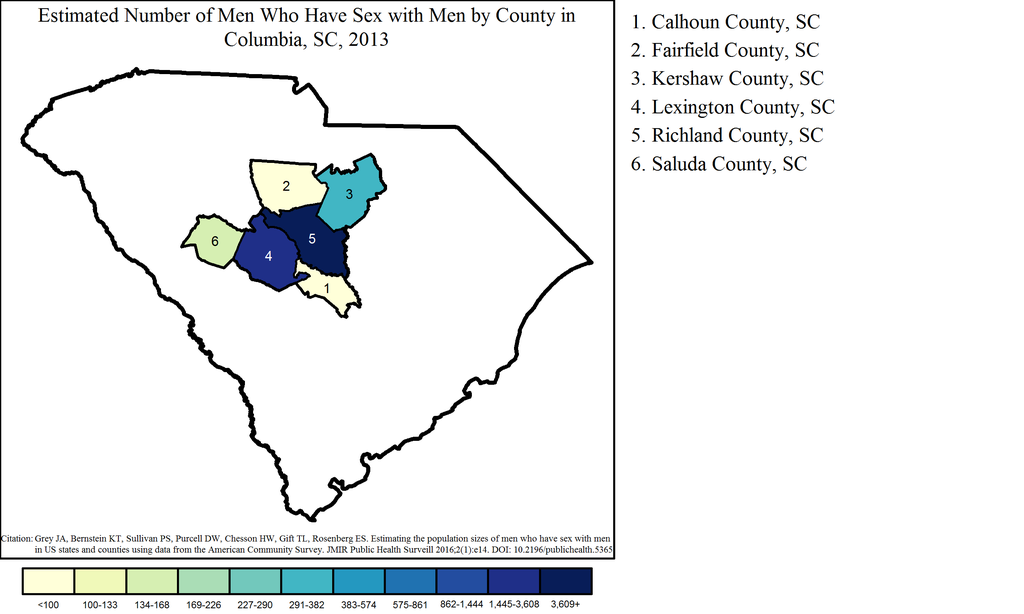

Note: Range cutpoints for the map are based on the distribution of MSM among all counties in the United States.

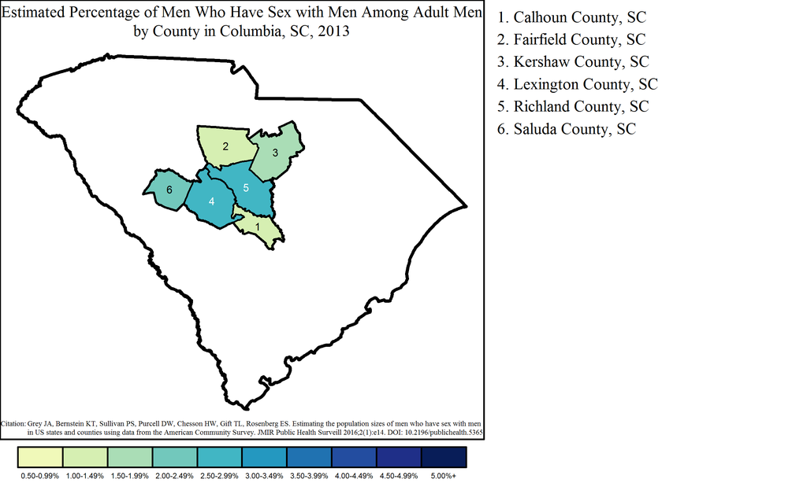

#### Charleston-North Charleston Metropolitan Statistical Area

The Charleston-North Charleston MSA had a population of 5,756 MSM, or 15.8% of all MSM in South Carolina. Of the 254,174 adult men in Charleston-North Charleston, an estimated 2.3% were MSM.

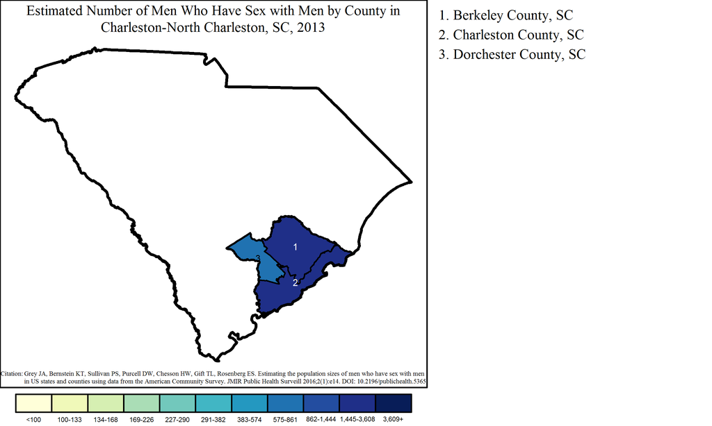

Note: Range cutpoints for the map are based on the distribution of MSM among all counties in the United States.

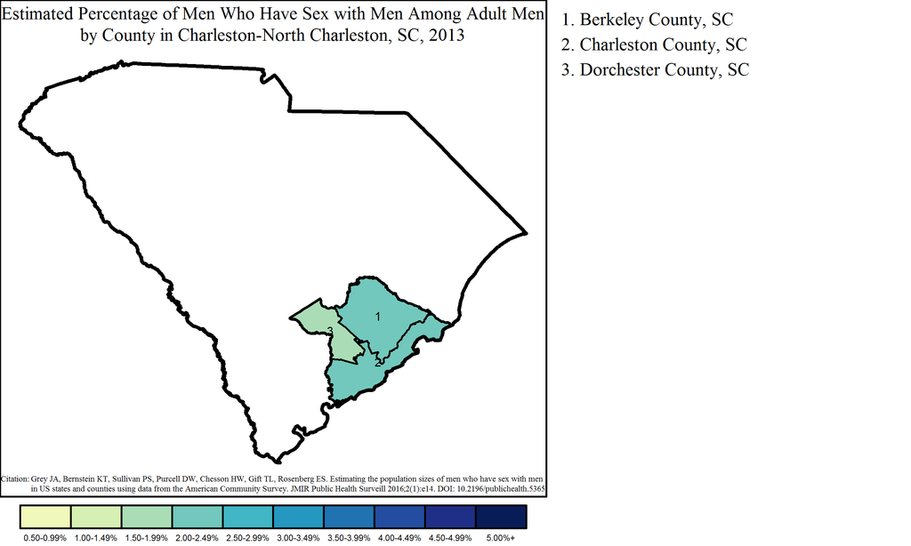

#### Greenville-Anderson-Mauldin Metropolitan Statistical Area

The Greenville-Anderson-Mauldin MSA had a population of 5,636 MSM, or 15.5% of all MSM in South Carolina. Of the 306,835 adult men in Greenville-Anderson-Mauldin, an estimated 1.8% were MSM.

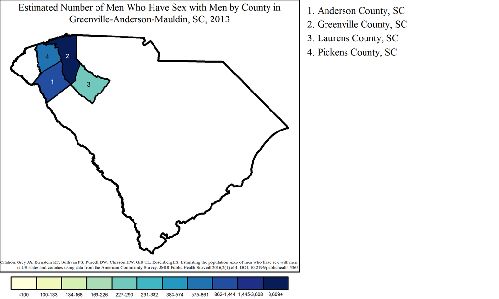

Note: Range cutpoints for the map are based on the distribution of MSM among all counties in the United States.

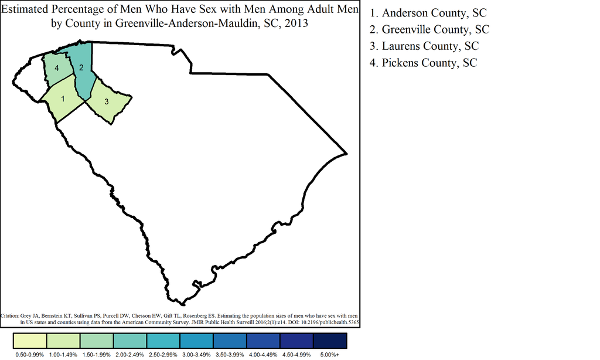

#### Charlotte-Concord-Gastonia Metropolitan Statistical Area

The Charlotte-Concord-Gastonia MSA overlaps two states: North Carolina and South Carolina. The South Carolina portion of the MSA had 3,889 MSM, or 10.7% of all MSM in the state and 11.0% of the 35,470 MSM in the MSA. Of 122,899 adult men in the South Carolina part of Charlotte-Concord-Gastonia, 3.2% were MSM. This was less than the overall percentage of MSM among adult men in the MSA, which was 4.4% of adult men (35,470 out of 807,928).

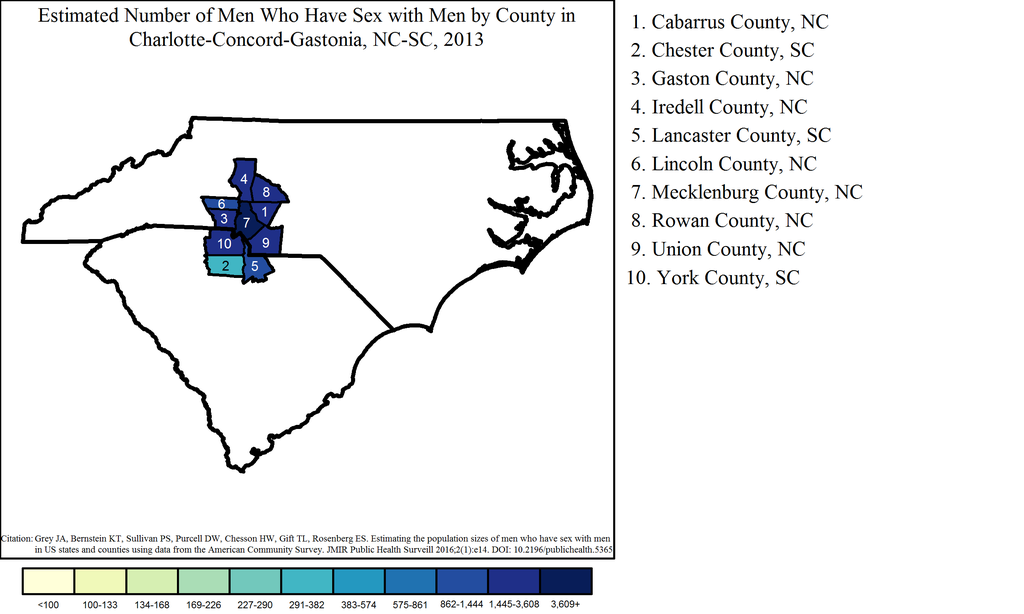

Note: Range cutpoints for the map are based on the distribution of MSM among all counties in the United States.

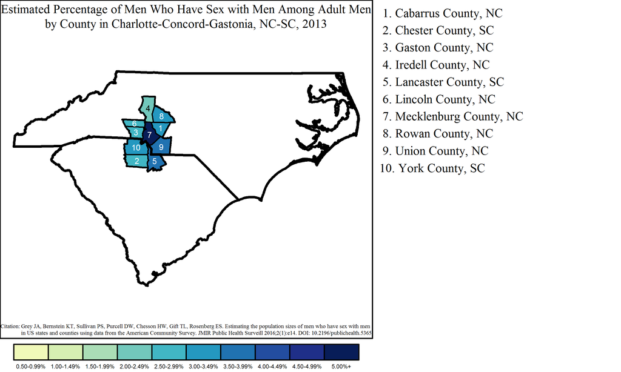

#### Myrtle Beach-Conway-North Myrtle Beach Metropolitan Statistical Area

The Myrtle Beach-Conway-North Myrtle Beach MSA overlaps two states: North Carolina and South Carolina. The South Carolina portion of the MSA had 2,179 MSM, or 6.0% of all MSM in the state and 72.2% of the 3,018 MSM in the MSA. Of 106,832 adult men in the South Carolina part of Myrtle Beach-Conway-North Myrtle Beach, 2.0% were MSM. This was equal to the overall percentage of MSM among adult men in the MSA, which was 2.0% of adult men (3,018 out of 150,218).

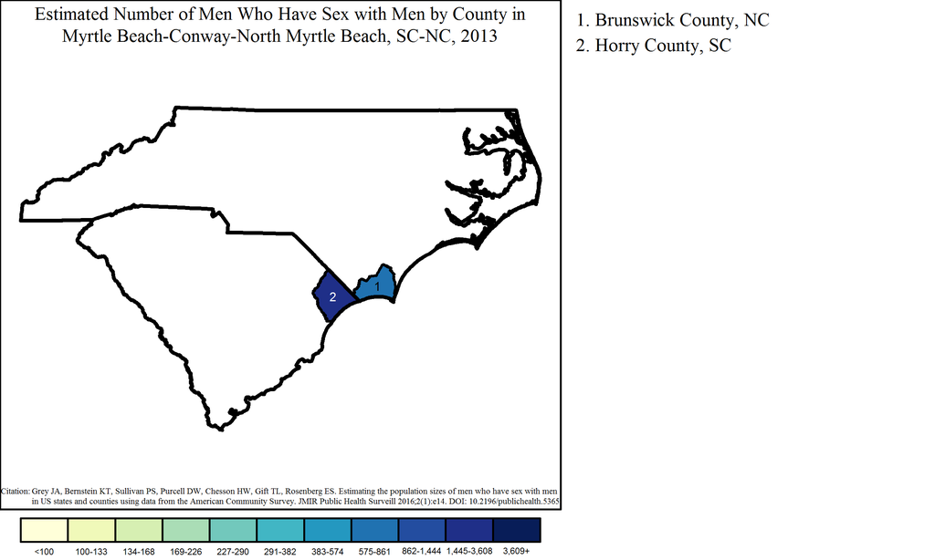

Note: Range cutpoints for the map are based on the distribution of MSM among all counties in the United States.

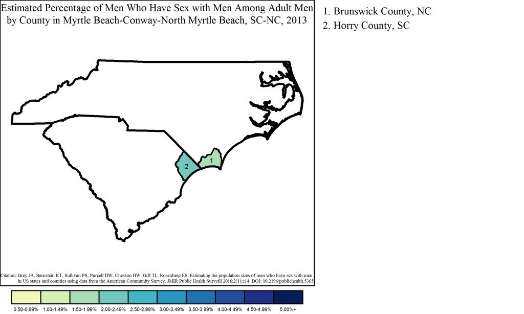

#### Spartanburg Metropolitan Statistical Area

The Spartanburg MSA had a population of 2,062 MSM, or 5.7% of all MSM in South Carolina. Of the 113,983 adult men in Spartanburg, an estimated 1.8% were MSM.

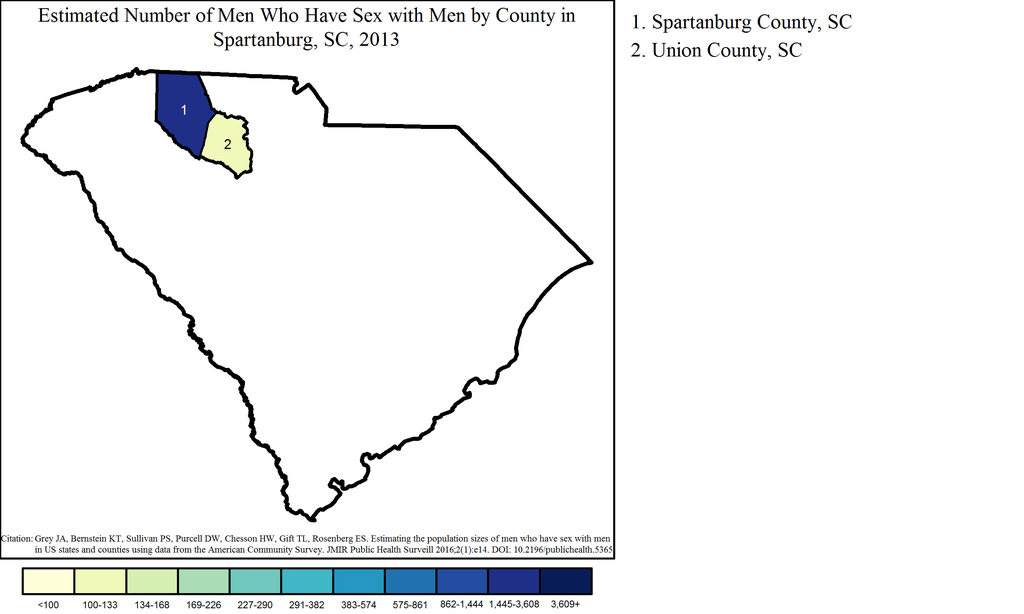

Note: Range cutpoints for the map are based on the distribution of MSM among all counties in the United States.

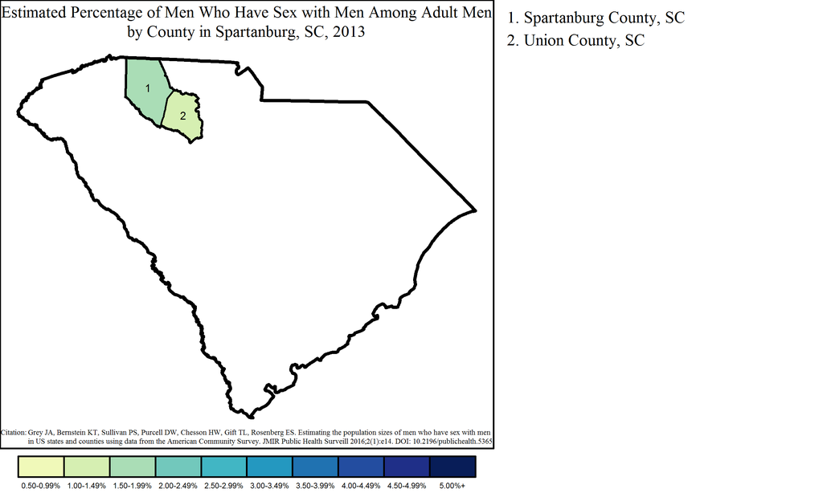

#### Hilton Head Island-Bluffton-Beaufort Metropolitan Statistical Area

The Hilton Head Island-Bluffton-Beaufort MSA had a population of 1,891 MSM, or 5.2% of all MSM in South Carolina. Of the 74,431 adult men in Hilton Head Island-Bluffton-Beaufort, an estimated 2.5% were MSM.

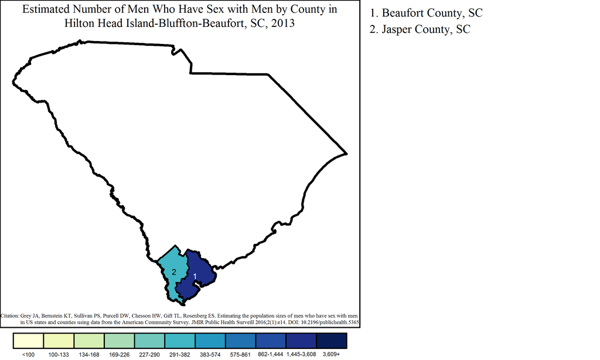

Note: Range cutpoints for the map are based on the distribution of MSM among all counties in the United States.

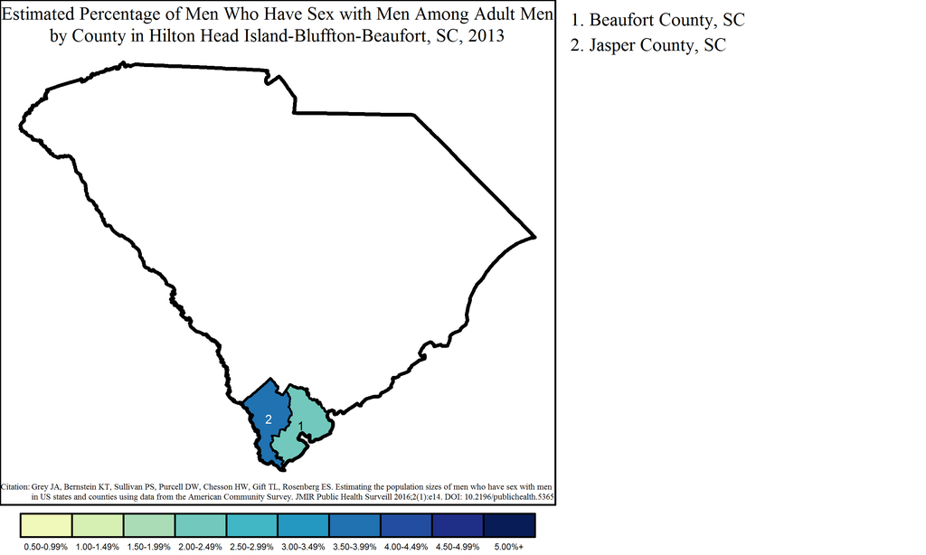

#### Augusta-Richmond County Metropolitan Statistical Area

The Augusta-Richmond County MSA overlaps two states: Georgia and South Carolina. The South Carolina portion of the MSA had 1,521 MSM, or 4.2% of all MSM in the state and 47.6% of the 3,194 MSM in the MSA. Of 71,296 adult men in the South Carolina part of Augusta-Richmond County, 2.1% were MSM. This was greater than the overall percentage of MSM among adult men in the MSA, which was 1.5% of adult men (3,194 out of 206,844).

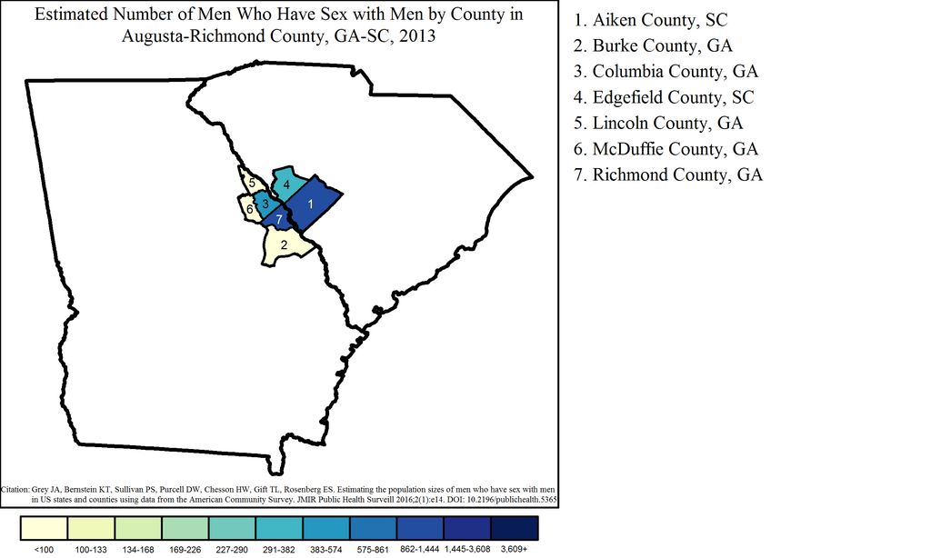

Note: Range cutpoints for the map are based on the distribution of MSM among all counties in the United States.

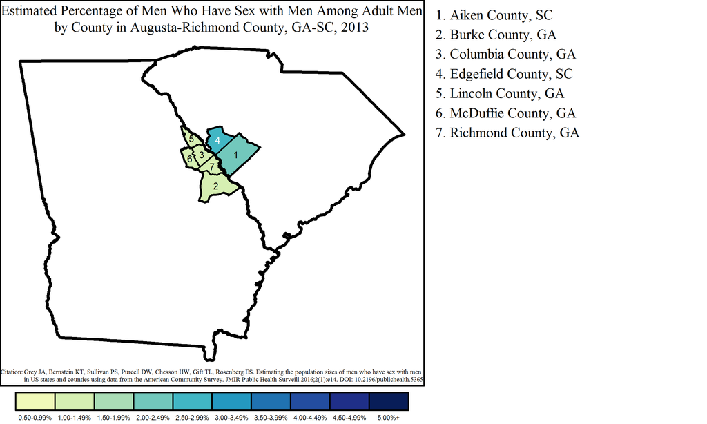

#### Florence Metropolitan Statistical Area

The Florence MSA had a population of 1,106 MSM, or 3.0% of all MSM in South Carolina. Of the 71,646 adult men in Florence, an estimated 1.5% were MSM.

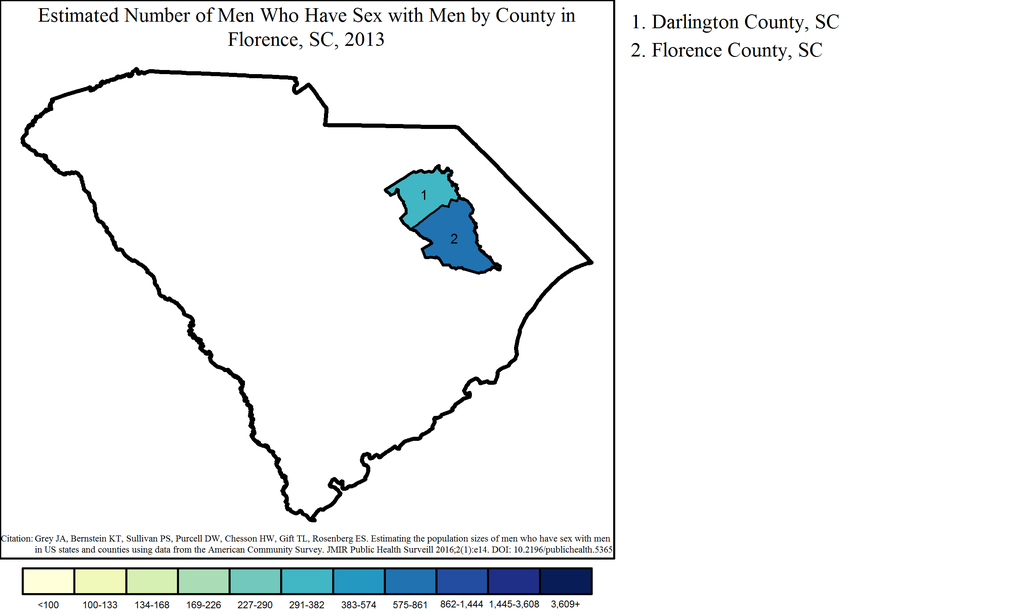

Note: Range cutpoints for the map are based on the distribution of MSM among all counties in the United States.

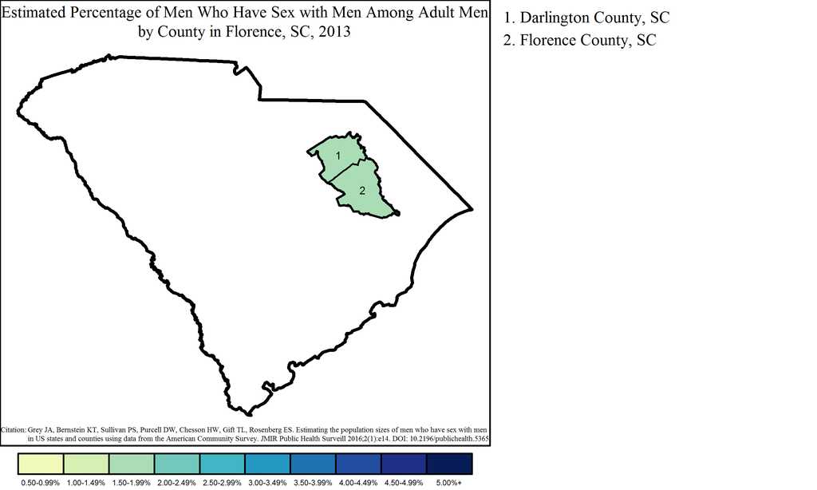

#### Sumter Metropolitan Statistical Area

The Sumter MSA had a population of 521 MSM, or 1.4% of all MSM in South Carolina. Of the 38,343 adult men in Sumter, an estimated 1.4% were MSM.

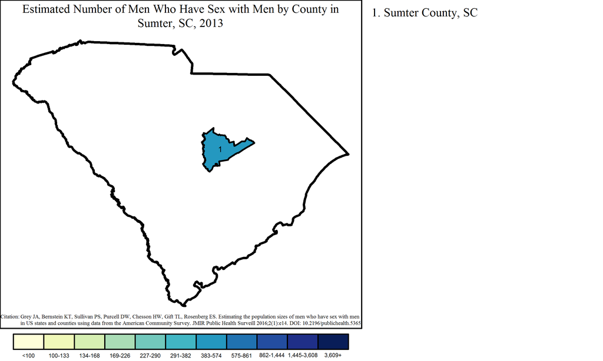

Note: Range cutpoints for the map are based on the distribution of MSM among all counties in the United States.

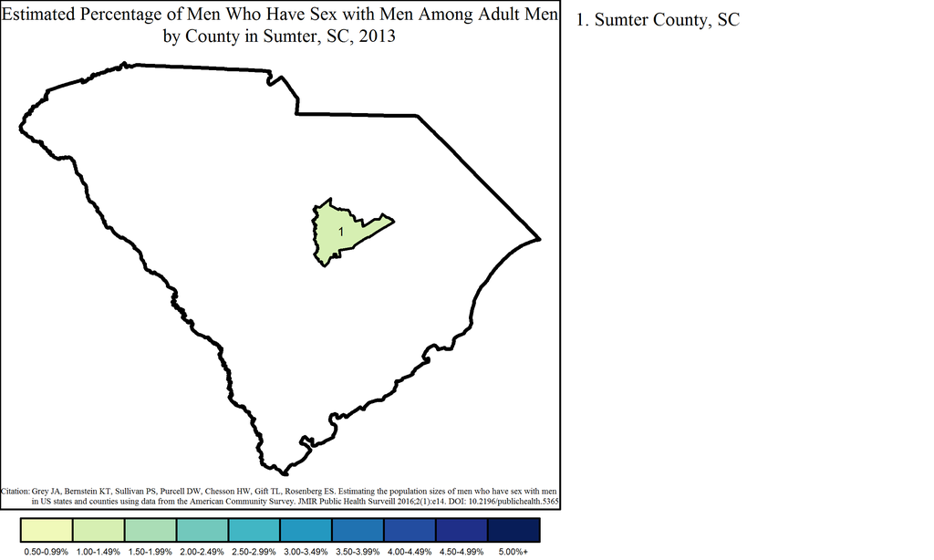